# Assignment #6

20141831 박석환

2020 5 27

### Sentiment Analysis on Movie Review Dataset

“imdb.csv” 파일은 화 리뷰 사이트인 IMDB로부터 추출한 10,000개의 화 리뷰 정보를 포함하며 다음 2개의 column으로 구성되어 있다. 데이터셋 중에서 5,028개는 평점 7점 이상을 기록한 positive 리뷰이며, 나머지 4,972개는 평점 4점 이하를 기록 한 negative 리뷰이다. 평점 5~6점을 기록한 리뷰는 데이터셋에 포함되지 않았다. 그리고 화 하나당 최대 30개 의 리뷰를 포함하고 있다. 본 과제에서는 화 리뷰 텍스트로부터 리뷰의 positive/negative 여부를 판별하기 위 한 모델을 만들어본다.

```r
# 라이브러리 import
library(wordcloud)
library(tm)
library(SnowballC)
library(caret)
library(rsample)
library(glmnet)
library(rpart)
library(rpart.plot)
library(randomForest)
library(ggplot2)
library(class)
library(gmodels)
library(ROCR)
```

#### 1. Positive 리뷰 텍스트와 negative 리뷰 텍스트의 word cloud를 각각 그려보자. 둘을 비교했을 때 어떠한 차이점을 발견할 수 있는가?

```r
# 1
imdb_raw <- read.csv("imdb.csv", stringsAsFactors = FALSE, encoding = "UTF-8")

# target 변수 factorize
imdb_raw$sentiment <- factor(imdb_raw$sentiment)
table(imdb_raw$sentiment)
```

```
##
## negative positive
##     4972     5028
```

```r
# 1. wordcloud그려보기
positive <- subset(imdb_raw, sentiment == "positive")
negative <- subset(imdb_raw, sentiment == "negative")
split.screen(c(1,2))
```

```
## [1] 1 2
```

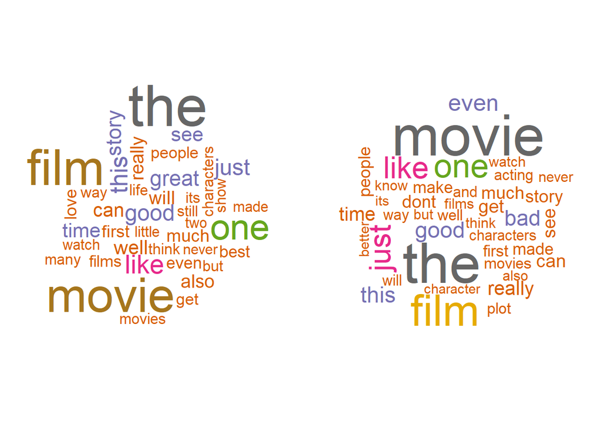

```r
screen(1)
wordcloud(positive$review, max.words = 40, colors = brewer.pal(8, "Dark2"))
screen(2)
wordcloud(negative$review, max.words = 40, colors = brewer.pal(8, "Dark2"))
```

- film, movie the와 같이 공통적으로 빈도 높게 출현하는 단어들이 있다.
- positive review에서는 best, love, good와 같이 긍정적인 단어가 포함되어있다.
- 반면, negative review에서는 bad와 같이 부정적인 단어가 포함된다.

#### 2. 전체 10,000개의 리뷰 텍스트를 대상으로 corpus를 생성하고 bag-of-words 기법을 적용하기 위해 적절한 preprocessing을 수행해보자.

**A. 강의노트에서 다룬 모든 preprocessing 단계를 순서대로 수행한다.**

```r
# 2-a
# coupus 생성
imdb_corpus <- VCorpus(VectorSource(imdb_raw$review))

# 대소문자 줄이기
imdb_corpus_clean <- tm_map(imdb_corpus, content_transformer(tolower))

# 숫자 제거
imdb_corpus_clean <- tm_map(imdb_corpus_clean, removeNumbers)

# stopworks 제거
imdb_corpus_clean <- tm_map(imdb_corpus_clean, removeWords, stopwords())

# 문장부호 제거
imdb_corpus_clean <- tm_map(imdb_corpus_clean, removePunctuation)

# semming
imdb_corpus_clean <- tm_map(imdb_corpus_clean, stemDocument)

# 공백제거
imdb_corpus_clean <- tm_map(imdb_corpus_clean, stripWhitespace)
```

**B. 모든 preprocessing 단계가 끝난 후, “movi”와 “ﬁlm”을 모든 텍스트에서 삭제하자. 이들은 대부분의 텍스트 에서 등장하기 때문에 feature로써 의미가 약하다고 할 수 있다. “movie”는 stemming에 의해 “movi”로 변 환되었음에 유의하자.**

```r
# 2-b
imdb_corpus_clean <- tm_map(imdb_corpus_clean, removeWords, c("movi", "film"))
```

**C. 원 텍스트와 preprocessing 후의 텍스트 사이에 어떤 변화가 있는지 리뷰 텍스트의 예를 들어 비교해보자.**

```r
# 2-c
imdb_corpus[[777]]
```

```
## <<PlainTextDocument>>
## Metadata:  7
## Content:  chars: 739
```

```r
imdb_corpus[[777]]$content
```

```
## [1] "This film is dreadful. It has absolutely zero laughs. Hebrew Hammer (Adam Goldberg) sets out to save Hannukah from Evil Santa (Andy Dick). Perhaps a promising enough basis for a plot, in actual fact the film does not progress beyond this premise. While there are some (far and few) nice touch…
```

```r
imdb_corpus_clean[[777]]
```

```
## <<PlainTextDocument>>
## Metadata:  7
## Content:  chars: 423
```

```r
imdb_corpus_clean[[777]]$content
```

```
## [1] " dread absolut zero laugh hebrew hammer adam goldberg set save hannukah evil santa andi dick perhap promis enough basi plot actual fact  progress beyond premis far nice touch plot relat coher labour hackney ultim mindless bore despit fact goldberg dick greer hammer clientlov interest quit co…
```

#### 3. Document-Term Matrix (DTM) 와 TF-IDF matrix를 생성하자. 그리고 출현 빈도 수가 낮은 단어(term)를 DTM과 TD-IDF matrix에서 제외한다. 이때 출현 빈도 수가 낮은 단어를 삭제한 기준은 무엇이며, 단어의 수 가 얼마나 줄어들었는가?

```r
# 3
imdb_dtm <- DocumentTermMatrix(imdb_corpus_clean)
imdb_dtm
```

```
## <<DocumentTermMatrix (documents: 10000, terms: 48702)>>
## Non-/sparse entries: 907736/486112264
## Sparsity           : 100%
## Maximal term length: 51
## Weighting          : term frequency (tf)
```

```r
inspect(imdb_dtm[1:5,])
```

```
## <<DocumentTermMatrix (documents: 5, terms: 48702)>>
## Non-/sparse entries: 422/243088
## Sparsity           : 100%
## Maximal term length: 51
## Weighting          : term frequency (tf)
## Sample             :
##     Terms
## Docs comedi jake just mattei one see show violenc watch well
##    1      0    0    2      0   1   0    4       4     3    1
##    2      1    0    0      0   1   1    0       0     1    3
##    3      3    0    0      0   1   1    0       0     1    1
##    4      0    4    2      0   0   1    0       0     1    1
##    5      0    0    0      4   6   1    0       0     1    0
```

```r
imdb_tfidf <- weightTfIdf(imdb_dtm)
imdb_tfidf
```

```
## <<DocumentTermMatrix (documents: 10000, terms: 48702)>>
## Non-/sparse entries: 907736/486112264
## Sparsity           : 100%
## Maximal term length: 51
## Weighting          : term frequency - inverse document frequency (normalized) (tf-idf)
```

```r
inspect(imdb_tfidf[1:5,])
```

```
## <<DocumentTermMatrix (documents: 5, terms: 48702)>>
## Non-/sparse entries: 422/243088
## Sparsity           : 100%
## Maximal term length: 51
## Weighting          : term frequency - inverse document frequency (normalized) (tf-idf)
## Sample             :
##     Terms
## Docs boogeyman    closet     drama  halliwel      jake    mattei    parent
##    1 0.0000000 0.0000000 0.0000000 0.0000000 0.0000000 0.0000000 0.0000000
##    2 0.0000000 0.0000000 0.0000000 0.3163741 0.0000000 0.0000000 0.0000000
##    3 0.0000000 0.0000000 0.0000000 0.0000000 0.0000000 0.0000000 0.0000000
##    4 0.1983517 0.2751792 0.2193202 0.0000000 0.6078498 0.0000000 0.2577226
##    5 0.0000000 0.0000000 0.0000000 0.0000000 0.0000000 0.3407106 0.0000000
##     Terms
## Docs   spotsbr     woodi  zombiebr
##    1 0.0000000 0.0000000 0.0000000
##    2 0.0000000 0.0000000 0.0000000
##    3 0.0000000 0.1941098 0.0000000
##    4 0.2252155 0.0000000 0.2082663
##    5 0.0000000 0.0000000 0.0000000
```

```r
imdb_dtm2 <- removeSparseTerms(imdb_dtm, 0.98)
imdb_dtm2
```

```
## <<DocumentTermMatrix (documents: 10000, terms: 869)>>
## Non-/sparse entries: 552791/8137209
## Sparsity           : 94%
## Maximal term length: 14
## Weighting          : term frequency (tf)
```

```r
inspect(imdb_dtm2[1:5,])
```

```
## <<DocumentTermMatrix (documents: 5, terms: 869)>>
## Non-/sparse entries: 251/4094
## Sparsity           : 94%
## Maximal term length: 14
## Weighting          : term frequency (tf)
## Sample             :
##     Terms
## Docs charact citi comedi just one see show violenc watch well
##    1       0    2      0    2   1   0    4       4     3    1
##    2       0    0      1    0   1   1    0       0     1    3
##    3       1    0      3    0   1   1    0       0     1    1
##    4       0    0      0    2   0   1    0       0     1    1
##    5       2    1      0    0   6   1    0       0     1    0
```

- 문서의 수가 많아 단어의 양이 많다.
- 전체 document중에 2% 미만의 document에서 발생하는 단어는 제외한다.
- 그 결과, 전체 단어 48702개 중 869개가 남는다.

```r
imdb_dtm3 <- removeSparseTerms(imdb_tfidf, 0.98)
imdb_dtm3
```

```
## <<DocumentTermMatrix (documents: 10000, terms: 869)>>
## Non-/sparse entries: 552791/8137209
## Sparsity           : 94%
## Maximal term length: 14
## Weighting          : term frequency - inverse document frequency (normalized) (tf-idf)
```

```r
inspect(imdb_dtm3[1:5,])
```

```
## <<DocumentTermMatrix (documents: 5, terms: 869)>>
## Non-/sparse entries: 251/4094
## Sparsity           : 94%
## Maximal term length: 14
## Weighting          : term frequency - inverse document frequency (normalized) (tf-idf)
## Sample             :
##     Terms
## Docs       citi    comedi     decid     drama    master    parent  thriller
##    1 0.06212840 0.0000000 0.0000000 0.0000000 0.0000000 0.0000000 0.0000000
##    2 0.00000000 0.0401231 0.0000000 0.0000000 0.1258979 0.0000000 0.0000000
##    3 0.00000000 0.1248274 0.0000000 0.0000000 0.0000000 0.0000000 0.0000000
##    4 0.00000000 0.0000000 0.1342808 0.2193202 0.0000000 0.2577226 0.1762796
##    5 0.04088792 0.0000000 0.0000000 0.0000000 0.0000000 0.0000000 0.0000000
##     Terms
## Docs   violenc      watch       well
##    1 0.1273768 0.02861164 0.01187195
##    2 0.0000000 0.01748489 0.06529574
##    3 0.0000000 0.01813248 0.02257137
##    4 0.0000000 0.02489374 0.03098781
##    5 0.0000000 0.01255326 0.00000000
```

#### 4. 첫 5,000개의 데이터를 training set으로, 나머지 5,000개의 데이터를 test set으로 설정한 후, training set 을 사용하여 리뷰텍스트의 positive/negative 여부를 판별하기 위한 predictive model을 만들어보자.

**A. Test set에 대한 classiﬁcation accuracy를 높이기 위한 모델을 자유롭게 만들어본다. 이때 지금까지 학습한 모델을 최소 2개 이상 만들어보고, 분석 과정과 결과를 report하자. 사용하는 모델, 모델에 포함되는 파라미터에 대한 튜닝, 모델에 포함되는 feature의 수, DTM/TF-IDF 사용 여부 등이 classiﬁcation accuracy에 향을 미칠 수 있다. [주의: 모델을 수립할 때에는 test set을 사용할 수 없다.]**

#### dtm

```r
# 4
# 데이터 프레임으로 바꾸기
imdb <- data.frame(as.matrix(imdb_dtm2))


# 적절한 이름으로 col명 지정해주기
colnames(imdb) <-make.names(colnames(imdb))

# target, test set으로 나누기
imdb$target <- imdb_raw$sentiment
imdb_train <- imdb[1:5000,]
imdb_test <- imdb[5001:10000,]
```

**model1. lasso regression**

feature의 수가 많은 경우이기 때문에 lasso regression을 사용하면 빠르게 해결할 수 있다.

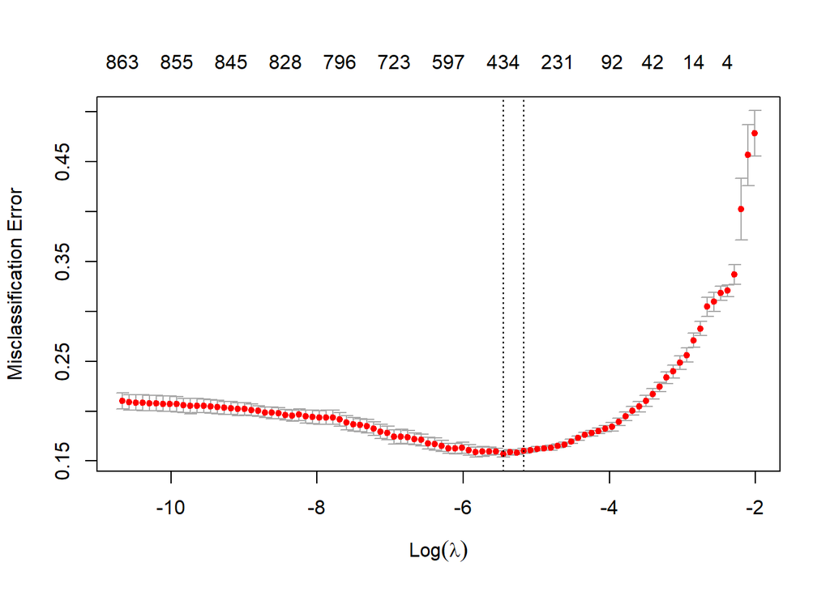

```r
# lasso
# 데이터 processing
set.seed(123)
train_x <- model.matrix(target~., imdb_train)[,-870]
train_y <- imdb_train$target
model_lasso <- cv.glmnet(x = train_x, y = train_y, alpha = 1, family = "binomial", type.measure = "class", nfolds = 5)
plot(model_lasso)
```

```r
# lambda 값 출력
model_lasso$lambda
```

```
##  [1] 1.335958e-01 1.217275e-01 1.109136e-01 1.010603e-01 9.208241e-02
##  [6] 8.390206e-02 7.644844e-02 6.965697e-02 6.346883e-02 5.783044e-02
## [11] 5.269294e-02 4.801185e-02 4.374661e-02 3.986028e-02 3.631920e-02
## [16] 3.309270e-02 3.015284e-02 2.747414e-02 2.503342e-02 2.280952e-02
## [21] 2.078318e-02 1.893686e-02 1.725456e-02 1.572171e-02 1.432504e-02
## [26] 1.305244e-02 1.189290e-02 1.083637e-02 9.873695e-03 8.996543e-03
## [31] 8.197315e-03 7.469088e-03 6.805555e-03 6.200968e-03 5.650091e-03
## [36] 5.148153e-03 4.690805e-03 4.274087e-03 3.894389e-03 3.548422e-03
## [41] 3.233190e-03 2.945962e-03 2.684251e-03 2.445790e-03 2.228512e-03
## [46] 2.030538e-03 1.850150e-03 1.685788e-03 1.536027e-03 1.399571e-03
## [51] 1.275237e-03 1.161948e-03 1.058724e-03 9.646698e-04 8.789712e-04
## [56] 8.008859e-04 7.297374e-04 6.649095e-04 6.058408e-04 5.520196e-04
## [61] 5.029797e-04 4.582963e-04 4.175825e-04 3.804857e-04 3.466844e-04
## [66] 3.158859e-04 2.878235e-04 2.622540e-04 2.389561e-04 2.177279e-04
## [71] 1.983855e-04 1.807615e-04 1.647032e-04 1.500714e-04 1.367395e-04
## [76] 1.245919e-04 1.135235e-04 1.034384e-04 9.424920e-05 8.587636e-05
## [81] 7.824735e-05 7.129607e-05 6.496232e-05 5.919125e-05 5.393286e-05
## [86] 4.914161e-05 4.477601e-05 4.079823e-05 3.717383e-05 3.387141e-05
## [91] 3.086237e-05 2.812064e-05 2.562248e-05 2.334625e-05
```

```r
# lmada 최소값
model_lasso$lambda.min
```

```
## [1] 0.004274087
```

```r
#
model_lasso$nzero
```

```
##  s0  s1  s2  s3  s4  s5  s6  s7  s8  s9 s10 s11 s12 s13 s14 s15 s16 s17 s18 s19
##   0   1   1   3   4   6   7   8  10  14  17  19  22  28  37  42  50  59  65  76
## s20 s21 s22 s23 s24 s25 s26 s27 s28 s29 s30 s31 s32 s33 s34 s35 s36 s37 s38 s39
##  82  92 108 118 127 150 170 193 208 231 264 281 302 318 352 379 395 434 455 478
## s40 s41 s42 s43 s44 s45 s46 s47 s48 s49 s50 s51 s52 s53 s54 s55 s56 s57 s58 s59
## 501 513 538 556 578 597 615 638 653 671 689 697 710 723 735 745 755 765 774 783
## s60 s61 s62 s63 s64 s65 s66 s67 s68 s69 s70 s71 s72 s73 s74 s75 s76 s77 s78 s79
## 786 796 800 806 811 814 816 820 826 828 834 836 837 837 840 843 843 845 846 848
## s80 s81 s82 s83 s84 s85 s86 s87 s88 s89 s90 s91 s92 s93
## 849 849 851 854 856 855 858 860 860 862 862 862 863 863
```

- 그래프와 결과를 통해 최적의 lambda를 찾는다.

```r
lambda <- model_lasso$lambda[38]
```

```r
# 선택된 모델에 대해 train set confusion matrix
prob_lasso <- predict(model_lasso, newx = model.matrix(target~., data=imdb_train)[,-870], s=lambda, type = "response")
pred_lasso <- predict(model_lasso, newx = model.matrix(target~., data=imdb_train)[,-870], s=lambda, type = "class")
confusionMatrix(factor(pred_lasso, levels = c("negative", "positive")), imdb_train$target, positive = "positive")
```

```
## Confusion Matrix and Statistics
##
##           Reference
## Prediction negative positive
##   negative     2239      237
##   positive      293     2231
##
##                Accuracy : 0.894
##                  95% CI : (0.8851, 0.9024)
##     No Information Rate : 0.5064
##     P-Value [Acc > NIR] : < 2e-16
##
##                   Kappa : 0.788
##
##  Mcnemar's Test P-Value : 0.01689
##
##             Sensitivity : 0.9040
##             Specificity : 0.8843
##          Pos Pred Value : 0.8839
##          Neg Pred Value : 0.9043
##              Prevalence : 0.4936
##          Detection Rate : 0.4462
##    Detection Prevalence : 0.5048
##       Balanced Accuracy : 0.8941
##
##        'Positive' Class : positive
##
```

```r
# 선택된 모델에 대해 test set confusion matrix
prob_lasso <- predict(model_lasso, newx = model.matrix(target~., data=imdb_test)[,-870], s=lambda, type = "response")
pred_lasso <- predict(model_lasso, newx = model.matrix(target~., data=imdb_test)[,-870], s=lambda, type = "class")
confusionMatrix(factor(pred_lasso, levels = c("negative", "positive")), imdb_test$target, positive = "positive")
```

```
## Confusion Matrix and Statistics
##
##           Reference
## Prediction negative positive
##   negative     2032      397
##   positive      408     2163
##
##                Accuracy : 0.839
##                  95% CI : (0.8285, 0.8491)
##     No Information Rate : 0.512
##     P-Value [Acc > NIR] : <2e-16
##
##                   Kappa : 0.6778
##
##  Mcnemar's Test P-Value : 0.7245
##
##             Sensitivity : 0.8449
##             Specificity : 0.8328
##          Pos Pred Value : 0.8413
##          Neg Pred Value : 0.8366
##              Prevalence : 0.5120
##          Detection Rate : 0.4326
##    Detection Prevalence : 0.5142
##       Balanced Accuracy : 0.8389
##
##        'Positive' Class : positive
##
```

- train set : 89.4%의 accuracy가 나온다.
- test set : 83.9%의 accuracy가 나온다.

**model2. Randomforest tree**

tree model 중 예측 정확도를 높이기 위해 Randomforest tree model을 적용한다.

```r
set.seed(123)
rf <- randomForest(target~., data=imdb_train, ntree=300 ,mtry=30)

# train set에 대한 class 예측
rf_pred_train <- predict(rf, newdata=imdb_train, type="class")

# confusion matrix 계산
confusionMatrix((rf_pred_train), factor(imdb_train$target), positive = "positive")
```

```
## Confusion Matrix and Statistics
##
##           Reference
## Prediction negative positive
##   negative     2532        0
##   positive        0     2468
##
##                Accuracy : 1
##                  95% CI : (0.9993, 1)
##     No Information Rate : 0.5064
##     P-Value [Acc > NIR] : < 2.2e-16
##
##                   Kappa : 1
##
##  Mcnemar's Test P-Value : NA
##
##             Sensitivity : 1.0000
##             Specificity : 1.0000
##          Pos Pred Value : 1.0000
##          Neg Pred Value : 1.0000
##              Prevalence : 0.4936
##          Detection Rate : 0.4936
##    Detection Prevalence : 0.4936
##       Balanced Accuracy : 1.0000
##
##        'Positive' Class : positive
##
```

```r
# test set에 대한 class 예측
rf_pred_test <- predict(rf, newdata=imdb_test, type="class")

# confusion matrix 계산
confusionMatrix(factor(rf_pred_test), factor(imdb_test$target), positive = "positive")
```

```
## Confusion Matrix and Statistics
##
##           Reference
## Prediction negative positive
##   negative     2031      485
##   positive      409     2075
##
##                Accuracy : 0.8212
##                  95% CI : (0.8103, 0.8317)
##     No Information Rate : 0.512
##     P-Value [Acc > NIR] : < 2e-16
##
##                   Kappa : 0.6425
##
##  Mcnemar's Test P-Value : 0.01213
##
##             Sensitivity : 0.8105
##             Specificity : 0.8324
##          Pos Pred Value : 0.8353
##          Neg Pred Value : 0.8072
##              Prevalence : 0.5120
##          Detection Rate : 0.4150
##    Detection Prevalence : 0.4968
##       Balanced Accuracy : 0.8215
##
##        'Positive' Class : positive
##
```

#### tfidf

```r
# 4
# 데이터 프레임으로 바꾸기
imdb <- data.frame(as.matrix(imdb_dtm3))


# 적절한 이름으로 col명 지정해주기
colnames(imdb) <-make.names(colnames(imdb))

# target, test set으로 나누기
imdb$target <- imdb_raw$sentiment
imdb_train <- imdb[1:5000,]
imdb_test <- imdb[5001:10000,]
```

**model1. lasso regression**

feature의 수가 많은 경우이기 때문에 lasso regression을 사용하면 빠르게 해결할 수 있다.

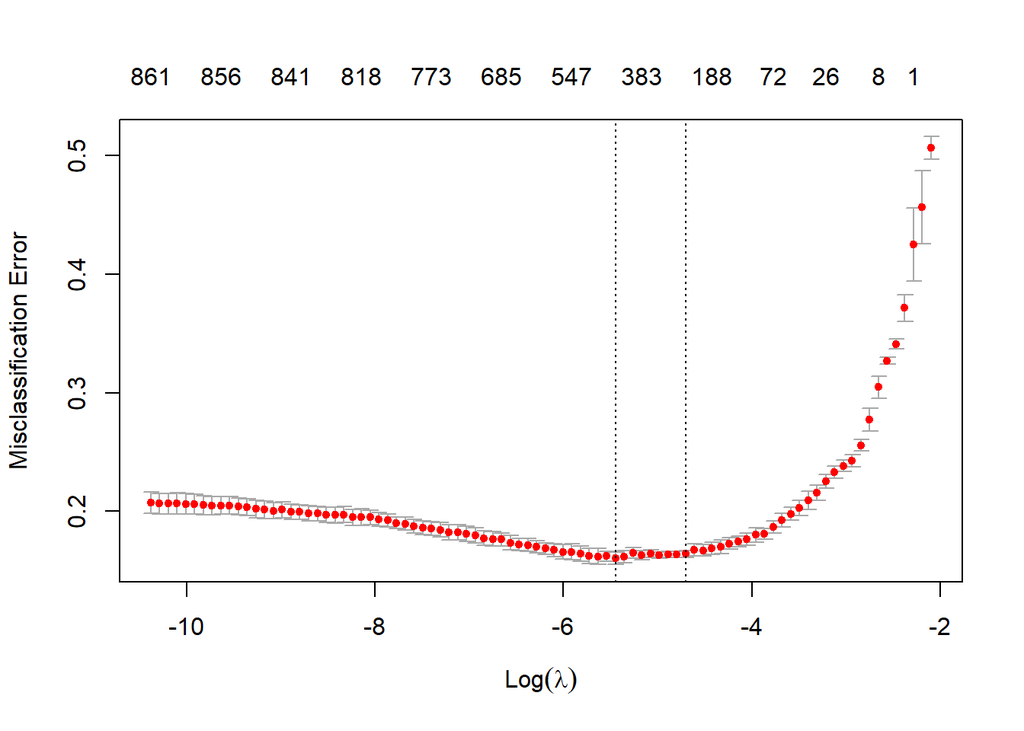

```r
# lasso
# 데이터 processing
set.seed(123)
train_x <- model.matrix(target~., imdb_train)[,-870]
train_y <- imdb_train$target
model_lasso <- cv.glmnet(x = train_x, y = train_y, alpha = 1, family = "binomial", type.measure = "class", nfolds = 5)
plot(model_lasso)
```

```r
# lambda 값 출력
model_lasso$lambda
```

```
##  [1] 1.226176e-01 1.117246e-01 1.017993e-01 9.275569e-02 8.451553e-02
##  [6] 7.700740e-02 7.016628e-02 6.393290e-02 5.825328e-02 5.307822e-02
## [11] 4.836289e-02 4.406647e-02 4.015172e-02 3.658475e-02 3.333467e-02
## [16] 3.037331e-02 2.767503e-02 2.521645e-02 2.297629e-02 2.093514e-02
## [21] 1.907532e-02 1.738072e-02 1.583667e-02 1.442978e-02 1.314788e-02
## [26] 1.197986e-02 1.091560e-02 9.945888e-03 9.062323e-03 8.257251e-03
## [31] 7.523700e-03 6.855315e-03 6.246308e-03 5.691403e-03 5.185794e-03
## [36] 4.725103e-03 4.305338e-03 3.922863e-03 3.574367e-03 3.256830e-03
## [41] 2.967502e-03 2.703878e-03 2.463673e-03 2.244807e-03 2.045384e-03
## [46] 1.863678e-03 1.698114e-03 1.547258e-03 1.409804e-03 1.284561e-03
## [51] 1.170444e-03 1.066465e-03 9.717232e-04 8.853980e-04 8.067417e-04
## [56] 7.350730e-04 6.697711e-04 6.102705e-04 5.560557e-04 5.066573e-04
## [61] 4.616473e-04 4.206358e-04 3.832677e-04 3.492192e-04 3.181955e-04
## [66] 2.899279e-04 2.641715e-04 2.407033e-04 2.193198e-04 1.998361e-04
## [71] 1.820832e-04 1.659074e-04 1.511687e-04 1.377393e-04 1.255029e-04
## [76] 1.143535e-04 1.041947e-04 9.493833e-05 8.650427e-05 7.881947e-05
## [81] 7.181736e-05 6.543731e-05 5.962404e-05 5.432720e-05 4.950092e-05
## [86] 4.510340e-05 4.109653e-05 3.744563e-05 3.411907e-05 3.108802e-05
```

```r
# lmada 최소값
model_lasso$lambda.min
```

```
## [1] 0.004305338
```

```r
#
model_lasso$nzero
```

```
##  s0  s1  s2  s3  s4  s5  s6  s7  s8  s9 s10 s11 s12 s13 s14 s15 s16 s17 s18 s19
##   0   1   1   4   5   6   8  12  15  17  19  24  26  32  38  48  56  63  72  86
## s20 s21 s22 s23 s24 s25 s26 s27 s28 s29 s30 s31 s32 s33 s34 s35 s36 s37 s38 s39
## 101 114 128 143 161 188 209 227 247 275 298 334 358 383 405 424 450 478 491 516
## s40 s41 s42 s43 s44 s45 s46 s47 s48 s49 s50 s51 s52 s53 s54 s55 s56 s57 s58 s59
## 526 547 568 585 601 608 629 648 667 685 697 715 722 729 738 751 757 773 784 792
## s60 s61 s62 s63 s64 s65 s66 s67 s68 s69 s70 s71 s72 s73 s74 s75 s76 s77 s78 s79
## 795 800 805 810 814 818 820 823 827 830 834 837 840 841 842 843 845 847 853 855
## s80 s81 s82 s83 s84 s85 s86 s87 s88 s89
## 855 856 856 857 857 857 858 858 860 861
```

- 그래프와 결과를 통해 최적의 lambda를 찾는다.

```r
lambda <- model_lasso$lambda[38]
```

```r
# 선택된 모델에 대해 train set confusion matrix
prob_lasso <- predict(model_lasso, newx = model.matrix(target~., data=imdb_train)[,-870], s=lambda, type = "response")
pred_lasso <- predict(model_lasso, newx = model.matrix(target~., data=imdb_train)[,-870], s=lambda, type = "class")
confusionMatrix(factor(pred_lasso, levels = c("negative", "positive")), imdb_train$target, positive = "positive")
```

```
## Confusion Matrix and Statistics
##
##           Reference
## Prediction negative positive
##   negative     2261      236
##   positive      271     2232
##
##                Accuracy : 0.8986
##                  95% CI : (0.8899, 0.9068)
##     No Information Rate : 0.5064
##     P-Value [Acc > NIR] : <2e-16
##
##                   Kappa : 0.7972
##
##  Mcnemar's Test P-Value : 0.131
##
##             Sensitivity : 0.9044
##             Specificity : 0.8930
##          Pos Pred Value : 0.8917
##          Neg Pred Value : 0.9055
##              Prevalence : 0.4936
##          Detection Rate : 0.4464
##    Detection Prevalence : 0.5006
##       Balanced Accuracy : 0.8987
##
##        'Positive' Class : positive
##
```

```r
# 선택된 모델에 대해 test set confusion matrix
prob_lasso <- predict(model_lasso, newx = model.matrix(target~., data=imdb_test)[,-870], s=lambda, type = "response")
pred_lasso <- predict(model_lasso, newx = model.matrix(target~., data=imdb_test)[,-870], s=lambda, type = "class")
confusionMatrix(factor(pred_lasso, levels = c("negative", "positive")), imdb_test$target, positive = "positive")
```

```
## Confusion Matrix and Statistics
##
##           Reference
## Prediction negative positive
##   negative     2031      397
##   positive      409     2163
##
##                Accuracy : 0.8388
##                  95% CI : (0.8283, 0.8489)
##     No Information Rate : 0.512
##     P-Value [Acc > NIR] : <2e-16
##
##                   Kappa : 0.6774
##
##  Mcnemar's Test P-Value : 0.6984
##
##             Sensitivity : 0.8449
##             Specificity : 0.8324
##          Pos Pred Value : 0.8410
##          Neg Pred Value : 0.8365
##              Prevalence : 0.5120
##          Detection Rate : 0.4326
##    Detection Prevalence : 0.5144
##       Balanced Accuracy : 0.8386
##
##        'Positive' Class : positive
##
```

- train set : 89.86%의 accuracy가 나온다.
- test set : 83.88%의 accuracy가 나온다.

**model2. Randomforest tree**

tree model 중 예측 정확도를 높이기 위해 Randomforest tree model을 적용한다.

```r
set.seed(123)
rf <- randomForest(target~., data=imdb_train, ntree=300 ,mtry=30)

# train set에 대한 class 예측
rf_pred_train <- predict(rf, newdata=imdb_train, type="class")

# confusion matrix 계산
confusionMatrix(factor(rf_pred_train), factor(imdb_train$target), positive = "positive")
```

```
## Confusion Matrix and Statistics
##
##           Reference
## Prediction negative positive
##   negative     2532        0
##   positive        0     2468
##
##                Accuracy : 1
##                  95% CI : (0.9993, 1)
##     No Information Rate : 0.5064
##     P-Value [Acc > NIR] : < 2.2e-16
##
##                   Kappa : 1
##
##  Mcnemar's Test P-Value : NA
##
##             Sensitivity : 1.0000
##             Specificity : 1.0000
##          Pos Pred Value : 1.0000
##          Neg Pred Value : 1.0000
##              Prevalence : 0.4936
##          Detection Rate : 0.4936
##    Detection Prevalence : 0.4936
##       Balanced Accuracy : 1.0000
##
##        'Positive' Class : positive
##
```

```r
# test set에 대한 class 예측
rf_pred_test <- predict(rf, newdata=imdb_test, type="class")

# confusion matrix 계산
confusionMatrix(factor(rf_pred_test), factor(imdb_test$target), positive = "positive")
```

```
## Confusion Matrix and Statistics
##
##           Reference
## Prediction negative positive
##   negative     2039      477
##   positive      401     2083
##
##                Accuracy : 0.8244
##                  95% CI : (0.8136, 0.8349)
##     No Information Rate : 0.512
##     P-Value [Acc > NIR] : < 2e-16
##
##                   Kappa : 0.6489
##
##  Mcnemar's Test P-Value : 0.01137
##
##             Sensitivity : 0.8137
##             Specificity : 0.8357
##          Pos Pred Value : 0.8386
##          Neg Pred Value : 0.8104
##              Prevalence : 0.5120
##          Detection Rate : 0.4166
##    Detection Prevalence : 0.4968
##       Balanced Accuracy : 0.8247
##
##        'Positive' Class : positive
##
```

- train set : train set model로 train set에 대한 예측이기에 1이 나온다.
- test set : 82.44%의 accuracy가 나온다.

**최종 모델**

- 83.9%의 accuracy를 갖고 있는 dtm data로 예측한 lasso model을 선택한다.